# Informe práctico 1

### **Parte 1**

**Pregunta:** ¿Cuáles y cuantos son los tipos de licencias utilizados en los paquetes?, ¿existe algun comportamiento particular en el uso de licencias entre las empresas?

**Introducción:** El siguiente dataframe titulado “runiverse” agrupa la totalidad de los paquetes R que conviven en el ecosistema de RStudio o también conocido como “R-Universe” hasta Abril de 2023 de la empresa Rstudio y la organización ROpenSci. Según ROpenSci, R-universe *“es un nuevo proyecto general bajo el cual experimentamos con varias ideas nuevas para mejorar la publicación y el descubrimiento de software de investigación en R.”*

En su estructura, el dataframe “runiverse” contiene 450 observaciones. Las mismas, contienen información agrupada en 14 variables: Package, Type, Title, Version, Description, License, Encoding, URL, Repository, Author, Maintainer, _published, _filesize, organization. De las cuales, todas contienen valores de tipo caracter a excepción de **filesize** que contiene valores de tipo entero.

**Enfoque:**  
Para responder a la primer pregunta fue necesario conocer los distintos tipos de licencias presentes en el dataframe.  
Para ello, se escribió unas pocas líneas de código que cumplieron la tarea de:

-Primero: recuperar sin repetir cada tipo de licencia con la función “distinct()” para luego convertir esa información en un vector. Esto fue útil para trabajar sólo con la variable “License” y así poder mostrar los tipos de licencias de una manera mas organizada.

-Segundo: con la función “cat()” se concatenó e imprimió cada tipo de licencia con un salto de linea y la suma total con la función “length”.

Esta es una excelente forma de imprimir una lista de manera ordenada y legible. Una vez hecho esto, con el dataframe original se ploteó un gráfico de barras que muestra la cantidad de observaciones por cada tipo de licencia y nos permite analizar de manera rápida y fácil sus dimensiones. Para el caso de la segunda pregunta, fue propicio realizar un gráfico de barras pero con la característica que pueda distinguir y agrupar los tipos de licencias por cada organización (Rstudio y ROpenSci).

**Analisis:**

```
## MIT + file LICENSE
## GPL-3
## GPL (>= 2)
## Apache License (>= 2.0)
## Apache License 2.0
## GPL-3 | file LICENSE
## GPL-2
## Apache License (>= 2)
## GPL (>= 2) | file LICENSE
## BSD_2_clause + file LICENSE
## Apache License 2.0 | file LICENSE
## BSD_3_clause + file LICENSE
## CC0
## GPL (>= 3)
## Apache License (== 2.0) | file LICENSE
## GPL-2 | file LICENSE
## Artistic-2.0
## GPL (>= 3)+ file LICENSE
## GPL (>=2)
## GPL-2 | GPL-3 | BSD_3_clause + file LICENSE
## GPL-2 | LGPL-2.1 | MPL-1.1
## AGPL-3
## Apache License (== 2.0)
## GPL-3 | BSD_2_clause + file LICENSE
## CC BY-SA 4.0
## GPL-3 + file LICENSE
## CC BY-NC-SA 4.0
## GPL
## CC0-1.0 + file LICENSE
##
## Total: 29
```

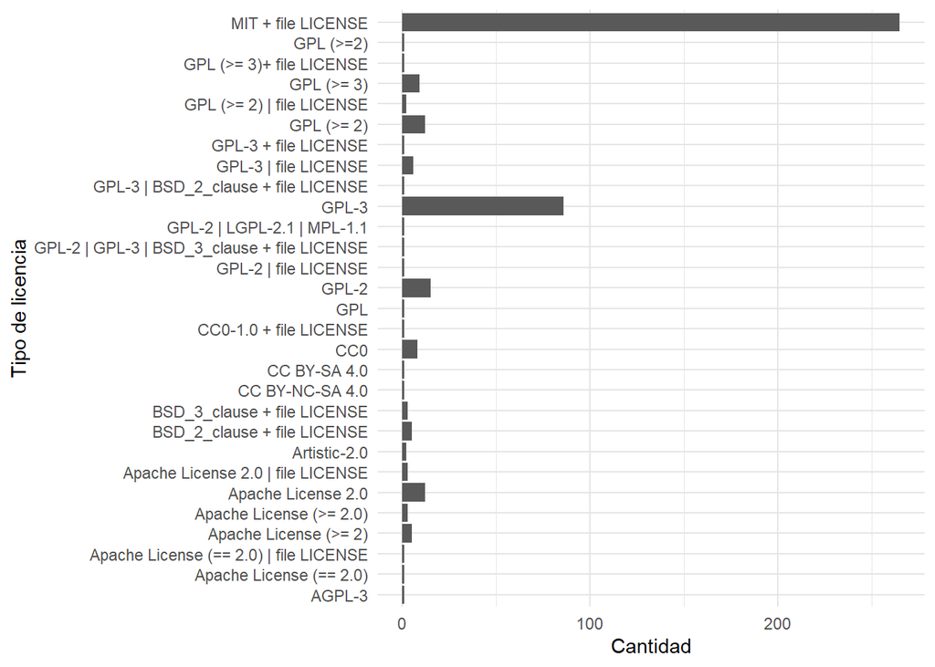

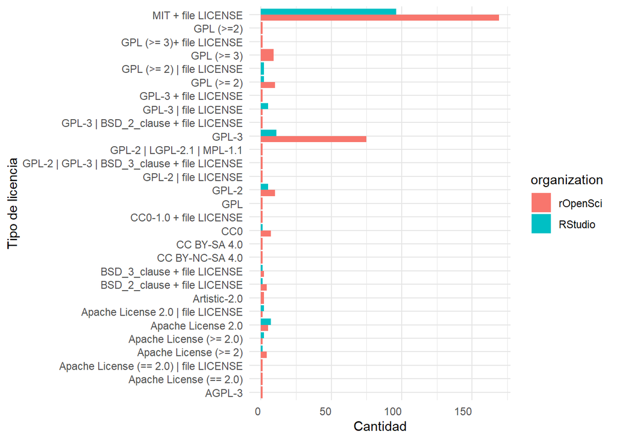

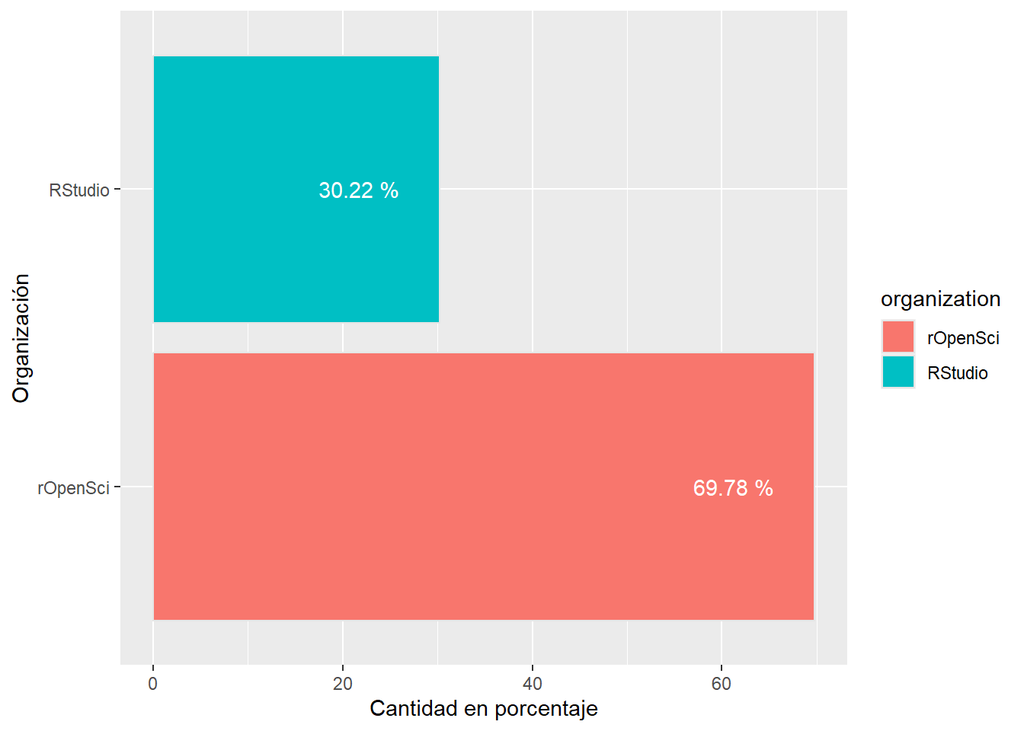

**Discusión:** Observando la gráfica 1 podemos notar que los tipos de licencias más usados por ambas organizaciones son **MIT + file LICENCE** y **GPL-3**. Lo que lleva a preguntarme:  
-¿Por qué estos tipos de licencia son más utilizados y no otros?, ¿Qué carácteristicas presentan MIT + file LICENCE y GPL-3 que las vuelven mas oportunas para Rstudio y ROpenSci?  
Realizando una investigación sobre estas licencias resultan ser las más populares para compartir software de código abierto. Esto va de la mano con la filosofía y la visión de R-Universe de impulsar la creación, investigación y divulgación de este tipo de herramientas y así enrobustecer la comunidad de R.  
La característica principal y que tienen en común ambos tipos de licencias es que permiten que cualquier persona use, copie, modifique, distribuya y venda el software, siempre y cuando se incluya una copia del aviso de derechos de autor y de la licencia original.  
El gráfico número 3 además nos muestra la proporción dada entre ambas organizaciones. ROpenSci posee casi el 70% de los paquetes y softwares desarrollados mientras que, Rstudio sólo el 30%. Cabe destacar que los 29 tipos de licencias de nuestro datframe promueven la distribución, copia o edición gratuita de los productos y esto acompaña el objetivo de R-Universe. Sin embargo, **MIT + file LICENCE** y **GPL-3** son las más usadas y aceptadas por la comunidad de R.

### **Parte 2**

**Pregunta:** ¿En que fecha se publicaron más paquetes?

**Introducción:** En esta ocasión se intenta conocer el día que mas publicaciones de paquetes se hizo y para eso he decidido trabajar con la variable “_published”. Las 450 observaciones estarán agrupadas según su fecha de publicación y oportunamente un gráfico nos permitirá visualizar esta distribución de la mejor manera posible.

**Enfoque:** Para responder a la pregunta fue necesario manipular los datos del dataframe para poder operar y generar los gráficos.  
El formato de la variable “_published” contenía no solo la fecha si no también la hora. Esto dificultaba el ánalisis ya que solo intentaba conocer el día, el mes y el año en el que fué publicado por lo que la hora era un dato innecesario al momento.

Para extraer la información relevante a la pregunta tuve que, con la función “as.Date” extraer la fecha. Pero la función me arrojaba un error relacionado al nombre de la variable. La variable “_published” contenía un carácter que impedía que la función realizara la extracción. Es por eso que primero tuve que modificar el nombre de la variable con la función “names” a “Published” y así poder continuar con el trabajo. Luego, creé un objeto que contenga la frecuencia de las fechas agrupadas y sin repetir. Con la función “count()” y “rename()” logré discriminar las 450 observaciones y juntarlas según la fecha de su publicación con su respectivas frecuencias absolutas.

**Analisis:**

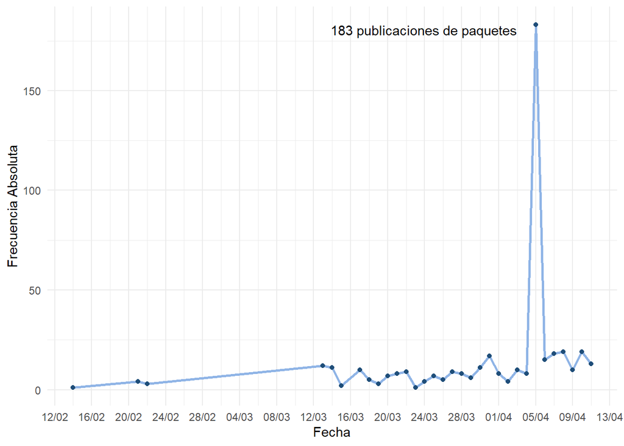